# RM 8.5 — Does Adding 2026 Observations to Training Improve Forecasts?

Maddee Wiggins (FlowWest)

2026-09-16

# Objective

The production models train on `rm_8_5_historical`, which ends 2025-10-29. A real RM 8.5 logger has since produced a full 2026 season. This document tests whether adding those observations to the training set improves forecasts, for both model formulations currently in use:

- the **change-from-today** target of `rm85-rf-delta.Rmd`, and
- the **absolute** target of `rm85-rf-dynamical.Rmd`.

The package data objects are not modified. Historical data is read from the package and the 2026 season is bound onto it at load time, so this document is self-contained and reversible.

## Two findings that shape the design

**2026 does not extend the temperature range of the historical record.** The `Potential improvements` note in `rm85-rf-delta.Rmd` states that 20% of 2026 days exceeded the training maximum. That is true of the *training partition* actually used (2021–2025 dynamical window, chronological 80%, maximum 24.06 °C), not of the historical record, whose May–October maximum is 24.92 °C — recorded in 2018, and slightly above 2026’s 24.89 °C. Zero 2026 days exceed the full historical maximum.

The constraint is therefore not a missing hot season. It is that moving to dynamical.org weather restricted training to 2021 onward, discarding earlier seasons — including 2018, which holds the record maximum. A longer-record variant is included below to test whether recovering those seasons is worth more than the 2026 addition.

Note that the longer record available is shorter than it first appears. `all_historical_forecasts` carries lead 0 (reanalysis) for 2011–2018 and leads 1–7 only from 2019 onward, so a model needing a forecast trajectory can reach back to 2019, not 2011.

**2026 is nonetheless an outlier — in sustained level rather than in peak.** The distinction matters for what adding it to training can be expected to do, and is clearest as a figure (Section 1d).

**2026 cannot be both training and test data.** Adding the season to training removes it as a clean evaluation set. This document uses a chronological cut: models are trained on data up to `train_cutoff` and evaluated on 2026 dates after it, using the real NWS forecasts logged operationally. The “with 2026” variants therefore see only the portion of 2026 preceding the cut.

```r
month_start   <- 5
month_end     <- 10
lead_days_vec <- 1:7
ntree         <- 500
trend_window  <- 5
threshold_7dadm <- 20.0
owrd_station  <- "14076100"

# Models train on data up to this date; evaluation uses 2026 dates after it.
train_cutoff <- as.Date("2026-06-30")

rm85_logger_file <- "WC85 Rimrock bottom 2026-08-13 09_52_44 PDT.xlsx"

lead_colors <- setNames(colorRampPalette(c("#185FA5", "#4E9F50", "#C93312"))(length(lead_days_vec)),
                        as.character(lead_days_vec))
```

# 1. Build the extended observation record

## 1a. RM 8.5: package historical + 2026 logger

```r
rm85_hist <- rm_8_5_historical |>
  mutate(date = as.Date(date)) |>
  filter(statistic %in% c("7DADM", "max")) |>
  select(date, statistic, temperature)

rm85_2026 <- readxl::read_xlsx(here("data-raw", "data-raw", rm85_logger_file)) |>
  janitor::clean_names() |>
  mutate(date = as.Date(floor_date(date_time_pdt, "1 day"))) |>
  group_by(date) |>
  summarise(max = max(temperature_c, na.rm = TRUE), .groups = "drop") |>
  arrange(date) |>
  mutate(`7DADM` = zoo::rollapply(max, 7, mean, fill = NA, align = "right")) |>
  pivot_longer(c(max, `7DADM`), names_to = "statistic", values_to = "temperature") |>
  filter(!is.na(temperature)) |>
  select(date, statistic, temperature)

# Bind, keeping the package record where the two overlap.
rm85_all <- bind_rows(rm85_hist, rm85_2026) |>
  distinct(date, statistic, .keep_all = TRUE) |>
  arrange(date, statistic)

rm85_7dadm <- rm85_all |> filter(statistic == "7DADM") |> select(date, rm_8_5_7dadm = temperature)
rm85_tmax  <- rm85_all |> filter(statistic == "max")   |> select(date, rm_8_5_tmax  = temperature)

cat(sprintf("RM 8.5 7DADM: %s .. %s (%d days; %d added from 2026 logger)\n",
            min(rm85_7dadm$date), max(rm85_7dadm$date), nrow(rm85_7dadm),
            sum(rm85_7dadm$date > max(rm85_hist$date))))
```

```
## RM 8.5 7DADM: 2011-04-28 .. 2026-08-13 (2990 days; 135 added from 2026 logger)
```

## 1b. Camp Polk: package historical + 2026 OWRD pull

The package objects end in April 2026, so the remainder of the season is pulled from OWRD and bound on.

```r
cp_hist_temp <- camp_polk_temperature_historical |> mutate(date = as.Date(date))
cp_hist_flow <- camp_polk_flow_historical        |> mutate(date = as.Date(date))

cp_pull_start <- max(cp_hist_flow$date) - 10
cp_pull_end   <- max(rm85_7dadm$date)

cp_flow_new <- get_owrd_hydro(owrd_station, cp_pull_start, cp_pull_end, "MDF") |>
  mutate(date = as.Date(parse_date_time(record_date, orders = c("mdy", "mdy HM")))) |>
  rename(cp_flow_mean = mean_daily_flow_cfs) |>
  select(date, cp_flow_mean) |> arrange(date)

cp_tmax_new <- get_owrd_hydro(owrd_station, cp_pull_start, cp_pull_end, "WTEMP15") |>
  mutate(date = as.Date(parse_date_time(record_date, orders = c("mdy", "mdy HM")))) |>
  group_by(date) |>
  summarise(cp_tmax = max(instantaneous_water_temp_c, na.rm = TRUE), .groups = "drop") |>
  arrange(date)

cp_flow <- bind_rows(
  cp_hist_flow |> filter(statistic == "mean") |> select(date, cp_flow_mean = flow_cfs),
  cp_flow_new
) |> distinct(date, .keep_all = TRUE) |> arrange(date)

cp_tmax <- bind_rows(
  cp_hist_temp |> filter(statistic == "max") |> select(date, cp_tmax = temperature),
  cp_tmax_new
) |> distinct(date, .keep_all = TRUE) |> arrange(date)

# 7DADM recomputed over the joined series so the seam is consistent.
cp_7dadm <- cp_tmax |> arrange(date) |>
  mutate(cp_7dadm = zoo::rollmean(cp_tmax, 7, fill = NA, align = "right")) |>
  select(date, cp_7dadm) |> filter(!is.na(cp_7dadm))

cat(sprintf("Camp Polk flow: %s .. %s | temp: %s .. %s\n",
            min(cp_flow$date), max(cp_flow$date), min(cp_tmax$date), max(cp_tmax$date)))
```

```
## Camp Polk flow: 2011-05-01 .. 2026-08-13 | temp: 2012-05-29 .. 2026-08-13
```

## 1c. Weather

```r
# Packaged snapshot of data-raw/dynamical_gfs_air_temp_historical.csv. Extend
# the CSV with data-raw/pull_dynamical_forecasts.py, then re-knit the
# dynamical.org chunk in data-raw/pull-historical-data.Rmd to refresh this.
dyn_raw <- dynamical_gfs_forecasts |>
  filter(lead_days %in% lead_days_vec) |>
  transmute(valid_date, lead_days, variable, value)

cat(sprintf("dynamical.org: %s .. %s\n", min(dyn_raw$valid_date), max(dyn_raw$valid_date)))
```

```
## dynamical.org: 2021-05-02 .. 2026-09-07
```

```r
om_raw <- all_historical_forecasts |>
  filter(lead_days %in% lead_days_vec) |>
  transmute(valid_date = as.Date(valid_date), lead_days, variable, value)

cat(sprintf("Open-Meteo (package): %s .. %s\n", min(om_raw$valid_date), max(om_raw$valid_date)))
```

```
## Open-Meteo (package): 2019-01-01 .. 2026-08-04
```

## 1d. How 2026 compares to the training years

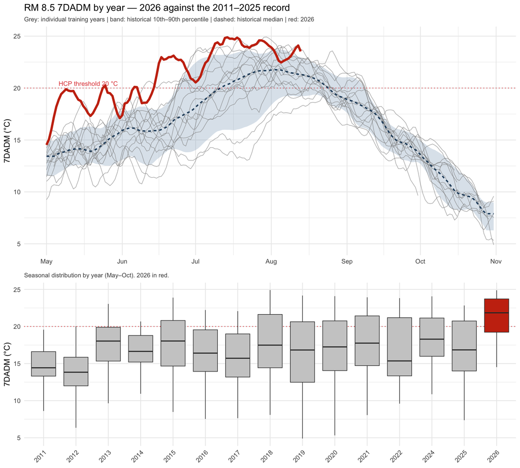

```r
library(cowplot)

season_all <- rm85_7dadm |>
  filter(!is.na(rm_8_5_7dadm), month(date) %in% month_start:month_end) |>
  mutate(year = year(date),
         doy_date = as.Date(paste0("2000-", format(date, "%m-%d"))))

historical <- season_all |> filter(year != 2026)
current    <- season_all |> filter(year == 2026)

# Historical 10th-90th percentile envelope by day-of-year, lightly smoothed.
env <- historical |>
  group_by(doy_date) |>
  summarise(lo = quantile(rm_8_5_7dadm, 0.10),
            md = median(rm_8_5_7dadm),
            hi = quantile(rm_8_5_7dadm, 0.90), .groups = "drop") |>
  arrange(doy_date) |>
  mutate(across(c(lo, md, hi), ~ zoo::rollapply(.x, 7, mean, fill = "extend", align = "center")))

p_season <- ggplot() +
  geom_ribbon(data = env, aes(doy_date, ymin = lo, ymax = hi), fill = "#9AB3C9", alpha = 0.35) +
  geom_line(data = historical, aes(doy_date, rm_8_5_7dadm, group = year),
            colour = "grey55", linewidth = 0.35, alpha = 0.65) +
  geom_line(data = env, aes(doy_date, md), colour = "#274C6B", linewidth = 0.9, linetype = "22") +
  geom_line(data = current, aes(doy_date, rm_8_5_7dadm), colour = "#C93312", linewidth = 1.5) +
  geom_hline(yintercept = threshold_7dadm, linetype = "dotted", colour = "#E24B4A") +
  annotate("text", x = as.Date("2000-05-06"), y = threshold_7dadm + 0.45,
           label = "HCP threshold 20 °C", hjust = 0, size = 3.1, colour = "#E24B4A") +
  scale_x_date(date_labels = "%b", date_breaks = "1 month") +
  labs(title = "RM 8.5 7DADM by year — 2026 against the 2011–2025 record",
       subtitle = "Grey: individual training years | band: historical 10th–90th percentile | dashed: historical median | red: 2026",
       x = NULL, y = "7DADM (°C)") +
  theme_minimal(base_size = 11) +
  theme(plot.subtitle = element_text(size = 8.5, colour = "grey30"))

p_box <- season_all |>
  mutate(is26 = year == 2026) |>
  ggplot(aes(factor(year), rm_8_5_7dadm, fill = is26)) +
  geom_hline(yintercept = threshold_7dadm, linetype = "dotted", colour = "#E24B4A") +
  geom_boxplot(outlier.size = 0.5, linewidth = 0.35) +
  scale_fill_manual(values = c(`FALSE` = "grey80", `TRUE` = "#C93312"), guide = "none") +
  labs(subtitle = "Seasonal distribution by year (May–Oct). 2026 in red.",
       x = NULL, y = "7DADM (°C)") +
  theme_minimal(base_size = 11) +
  theme(axis.text.x = element_text(angle = 45, hjust = 1),
        plot.subtitle = element_text(size = 8.5, colour = "grey30"))

plot_grid(p_season, p_box, ncol = 1, rel_heights = c(1.35, 1), align = "v", axis = "lr")
```

```r
yr <- season_all |> group_by(year) |> summarise(n = n(), mean = mean(rm_8_5_7dadm),
                                                max = max(rm_8_5_7dadm), .groups = "drop")
above <- current |> left_join(env |> select(doy_date, hi), by = "doy_date") |> filter(!is.na(hi))

tibble(
  metric = c("2026 seasonal mean (°C)",
             "2011–2025 mean of seasonal means (°C)",
             "2026 anomaly (°C)",
             "2026 rank by seasonal mean (1 = warmest)",
             "2026 seasonal maximum (°C)",
             "Historical maximum, 2011–2025 (°C)",
             "% of 2026 days above the historical 90th pct for that day-of-year"),
  value = c(round(yr$mean[yr$year == 2026], 2),
            round(mean(yr$mean[yr$year != 2026]), 2),
            round(yr$mean[yr$year == 2026] - mean(yr$mean[yr$year != 2026]), 2),
            rank(-yr$mean)[yr$year == 2026],
            round(yr$max[yr$year == 2026], 2),
            round(max(yr$max[yr$year != 2026]), 2),
            round(mean(above$rm_8_5_7dadm > above$hi) * 100, 0))
) |> kable()
```

| metric | value |
| --- | --- |
| 2026 seasonal mean (°C) | 21.28 |
| 2011–2025 mean of seasonal means (°C) | 16.67 |
| 2026 anomaly (°C) | 4.61 |
| 2026 rank by seasonal mean (1 = warmest) | 1.00 |
| 2026 seasonal maximum (°C) | 24.89 |
| Historical maximum, 2011–2025 (°C) | 24.92 |
| % of 2026 days above the historical 90th pct for that day-of-year | 80.00 |

The figure separates two things that are easy to conflate. 2026 sits above the historical 10th–90th percentile band for most of the season — 80% of its days exceed the historical 90th percentile for that day-of-year, and its seasonal mean is the highest on record by a wide margin. But its **peak** does not set a record: 24.89 °C against 24.92 °C in 2018.

For this experiment that means 2026 contributes densely sampled warm conditions and a post-2022-regime signal, but does not extend the upper bound of the training range. Any improvement from including it should therefore be expected in the ordinary warm range rather than at the extreme — which is what Section 6 finds.

# 2. Feature construction

Identical to `rm85-rf-delta.Rmd`, with the weather source switchable so the long-record variant in Section 6 can reuse it.

```r
get_forecast_src <- function(src, lead_k) {
  tbl <- if (src == "dyn") dyn_raw else om_raw
  tbl |> filter(lead_days == lead_k) |>
    select(valid_date, variable, value) |>
    pivot_wider(names_from = variable, values_from = value) |>
    rename(date = valid_date, air_max = temperature_2m_max,
           air_min = temperature_2m_min, cloud_pct = cloud_cover_mean)
}

get_trajectory <- function(src, lead_k) {
  reduce(map(seq_len(lead_k), function(k) {
    get_forecast_src(src, k) |> mutate(run_date = date - k) |>
      transmute(run_date,
        !!paste0("air_max_d", k) := air_max,
        !!paste0("air_min_d", k) := air_min,
        !!paste0("cloud_d",   k) := cloud_pct,
        !!paste0("julian_d",  k) := yday(date))
  }), full_join, by = "run_date") |> arrange(run_date)
}

add_trajectory_summaries <- function(df, lead_k) {
  amx <- as.matrix(df[, paste0("air_max_d", 1:lead_k), drop = FALSE])
  amn <- as.matrix(df[, paste0("air_min_d", 1:lead_k), drop = FALSE])
  df$traj_air_max_max  <- apply(amx, 1, max)
  df$traj_air_max_mean <- apply(amx, 1, mean)
  df$traj_air_min_mean <- apply(amn, 1, mean)
  df$traj_warming      <- amx[, lead_k] - amx[, 1]
  df
}

build_df <- function(src, lead_k) {
  ft <- get_trajectory(src, lead_k) |> mutate(date = run_date + lead_k) |> select(-run_date)

  joined <- rm85_7dadm |>
    left_join(cp_flow  |> mutate(date = date + lead_k), by = "date") |>
    left_join(cp_7dadm |> mutate(date = date + lead_k), by = "date") |>
    left_join(cp_tmax  |> mutate(date = date + lead_k), by = "date") |>
    left_join(ft, by = "date") |>
    left_join(cp_flow  |> mutate(date = date + lead_k + 1)            |> rename(cp_flow_m1  = cp_flow_mean), by = "date") |>
    left_join(cp_flow  |> mutate(date = date + lead_k + trend_window) |> rename(cp_flow_mw  = cp_flow_mean), by = "date") |>
    left_join(cp_7dadm |> mutate(date = date + lead_k + 1)            |> rename(cp_7dadm_m1 = cp_7dadm),     by = "date") |>
    left_join(cp_7dadm |> mutate(date = date + lead_k + trend_window) |> rename(cp_7dadm_mw = cp_7dadm),     by = "date") |>
    left_join(rm85_7dadm |> mutate(date = date + lead_k)                |> rename(dadm_m0 = rm_8_5_7dadm), by = "date") |>
    left_join(rm85_tmax  |> mutate(date = date + lead_k)                |> rename(tmax_m0 = rm_8_5_tmax),  by = "date") |>
    left_join(rm85_7dadm |> mutate(date = date + lead_k + trend_window) |> rename(dadm_mw = rm_8_5_7dadm), by = "date") |>
    left_join(rm85_tmax  |> mutate(date = date + lead_k + trend_window) |> rename(tmax_mw = rm_8_5_tmax),  by = "date") |>
    mutate(
      cp_flow_trend  = (cp_flow_m1  - cp_flow_mw)  / (trend_window - 1),
      cp_7dadm_trend = (cp_7dadm_m1 - cp_7dadm_mw) / (trend_window - 1),
      dadm_trend     = (dadm_m0 - dadm_mw) / trend_window,
      tmax_trend     = (tmax_m0 - tmax_mw) / trend_window,
      month = month(date)
    ) |>
    filter(month >= month_start, month <= month_end) |>
    drop_na() |> distinct(date, .keep_all = TRUE) |> arrange(date)

  add_trajectory_summaries(joined, lead_k)
}

get_model_features <- function(lead_k) {
  c("cp_flow_mean", "cp_7dadm", "cp_tmax", "cp_flow_trend", "cp_7dadm_trend",
    paste0("air_max_d", 1:lead_k), paste0("air_min_d", 1:lead_k),
    paste0("cloud_d", 1:lead_k), paste0("julian_d", 1:lead_k),
    "dadm_m0", "tmax_m0", "dadm_trend", "tmax_trend",
    "traj_air_max_max", "traj_air_max_mean", "traj_air_min_mean", "traj_warming")
}

# `delta = TRUE` fits the change from dadm_m0; `FALSE` fits the level.
fit_model <- function(train_df, features, delta, seed = 42) {
  d <- train_df[, features, drop = FALSE]
  d$..y.. <- if (delta) train_df$rm_8_5_7dadm - train_df$dadm_m0 else train_df$rm_8_5_7dadm
  set.seed(seed)
  randomForest(..y.. ~ ., data = d, ntree = ntree,
               mtry = max(1, floor(length(features) / 3)))
}

predict_model <- function(model, newdata, delta) {
  p <- predict(model, newdata)
  if (delta) p + newdata$dadm_m0 else p
}

rmse <- function(pred, obs) sqrt(mean((pred - obs)^2))
```

# 3. Training sets

Each variant is defined by weather source, target formulation, and whether 2026 observations up to `train_cutoff` are included.

```r
dfs <- list(
  dyn = map(lead_days_vec, ~ build_df("dyn", .x)) |> set_names(as.character(lead_days_vec)),
  om  = map(lead_days_vec, ~ build_df("om",  .x)) |> set_names(as.character(lead_days_vec))
)

train_rows <- function(src, lead_k, include_2026) {
  d <- dfs[[src]][[as.character(lead_k)]]
  if (include_2026) d |> filter(date <= train_cutoff)
  else              d |> filter(date <= train_cutoff, year(date) < 2026)
}

map_dfr(c("dyn", "om"), function(src) {
  map_dfr(c(FALSE, TRUE), function(inc) {
    d <- train_rows(src, 1, inc)
    tibble(source = src, includes_2026 = inc, n_train = nrow(d),
           first = min(d$date), last = max(d$date), max_7dadm = max(d$rm_8_5_7dadm))
  })
}) |> kable(digits = 2)
```

| source | includes_2026 | n_train | first | last | max_7dadm |
| --- | --- | --- | --- | --- | --- |
| dyn | FALSE | 699 | 2021-05-02 | 2025-10-29 | 24.06 |
| dyn | TRUE | 760 | 2021-05-02 | 2026-06-30 | 24.06 |
| om | FALSE | 1068 | 2019-05-01 | 2025-10-29 | 24.17 |
| om | TRUE | 1129 | 2019-05-01 | 2026-06-30 | 24.17 |

# 4. Fit all variants

```r
VARIANTS <- tribble(
  ~name,                    ~src,  ~delta, ~inc2026,
  "delta_dyn_no2026",       "dyn", TRUE,   FALSE,
  "delta_dyn_with2026",     "dyn", TRUE,   TRUE,
  "absolute_dyn_no2026",    "dyn", FALSE,  FALSE,
  "absolute_dyn_with2026",  "dyn", FALSE,  TRUE,
  "delta_om_no2026",        "om",  TRUE,   FALSE,
  "delta_om_with2026",      "om",  TRUE,   TRUE
)

models <- pmap(VARIANTS, function(name, src, delta, inc2026) {
  map(lead_days_vec, function(k) {
    fit_model(train_rows(src, k, inc2026), get_model_features(k), delta)
  }) |> set_names(as.character(lead_days_vec))
}) |> set_names(VARIANTS$name)

cat("Fitted", nrow(VARIANTS), "variants x", length(lead_days_vec), "leads\n")
```

```
## Fitted 6 variants x 7 leads
```

# 5. Evaluation on held-out 2026 with real NWS inputs

Forecast dates after `train_cutoff`, with weather predictors taken from the operational NWS log rather than from either archive.

```r
nws_cached <- read_csv(here("output", "nws-forecasts-log.csv")) |>
  mutate(run_date = as.Date(run_date), forecast_date = as.Date(forecast_date))

rm_8_5_wide <- rm85_7dadm |>
  left_join(rm85_tmax, by = "date") |>
  rename(actual_7dadm_C = rm_8_5_7dadm, actual_tmax_C = rm_8_5_tmax)

hindcast_run_dates <- nws_cached |>
  distinct(run_date) |>
  filter(run_date %in% rm_8_5_wide$date, run_date > train_cutoff) |>
  pull(run_date) |> sort()

cat(sprintf("Held-out run dates: %d (%s .. %s)\n", length(hindcast_run_dates),
            min(hindcast_run_dates), max(hindcast_run_dates)))
```

```
## Held-out run dates: 38 (2026-07-01 .. 2026-08-13)
```

```r
cp_daily <- cp_flow |> left_join(cp_tmax, by = "date") |> left_join(cp_7dadm, by = "date")

safe1 <- function(x) if (length(x) == 0) NA_real_ else x
nws_daily <- function(var, target_date, agg_fn, run_date_val) {
  v <- nws_cached |> filter(run_date == run_date_val, variable == var,
                            forecast_date == target_date) |> pull(value)
  if (length(v) == 0) return(NA_real_)
  agg_fn(v, na.rm = TRUE)
}

build_hindcast_row <- function(rd, k) {
  ct <- cp_daily |> filter(date == rd)
  cy <- cp_daily |> filter(date == rd - 1)
  cw <- cp_daily |> filter(date == rd - trend_window)
  r0 <- rm_8_5_wide |> filter(date == rd)
  rw <- rm_8_5_wide |> filter(date == rd - trend_window)

  traj <- map(1:k, function(d) tibble(
    !!paste0("air_max_d", d) := nws_daily("maxTemperature", rd + d, max,  rd),
    !!paste0("air_min_d", d) := nws_daily("minTemperature", rd + d, min,  rd),
    !!paste0("cloud_d",   d) := nws_daily("skyCover",       rd + d, mean, rd),
    !!paste0("julian_d",  d) := yday(rd + d))) |> bind_cols()

  bind_cols(
    tibble(run_date = rd, forecast_date = rd + k, lead_days = k,
           cp_flow_mean   = safe1(ct$cp_flow_mean),
           cp_7dadm       = safe1(ct$cp_7dadm),
           cp_tmax        = safe1(ct$cp_tmax),
           cp_flow_trend  = (safe1(cy$cp_flow_mean) - safe1(cw$cp_flow_mean)) / (trend_window - 1),
           cp_7dadm_trend = (safe1(cy$cp_7dadm)     - safe1(cw$cp_7dadm))     / (trend_window - 1)),
    traj,
    tibble(dadm_m0 = safe1(r0$actual_7dadm_C), tmax_m0 = safe1(r0$actual_tmax_C),
           dadm_trend = (safe1(r0$actual_7dadm_C) - safe1(rw$actual_7dadm_C)) / trend_window,
           tmax_trend = (safe1(r0$actual_tmax_C)  - safe1(rw$actual_tmax_C))  / trend_window))
}

grid <- expand_grid(run_date = hindcast_run_dates, lead_days = lead_days_vec)
hin  <- map2_dfr(grid$run_date, grid$lead_days, build_hindcast_row)
hin_by_lead <- map(lead_days_vec, ~ add_trajectory_summaries(hin |> filter(lead_days == .x), .x)) |>
  set_names(as.character(lead_days_vec))
```

```r
evaluate_variant <- function(name, delta) {
  map_dfr(lead_days_vec, function(k) {
    rows <- hin_by_lead[[as.character(k)]]
    f <- get_model_features(k)
    ok <- complete.cases(rows[, c(f, "dadm_m0"), drop = FALSE])
    if (!any(ok)) return(NULL)
    rows <- rows[ok, , drop = FALSE]
    rows$pred <- predict_model(models[[name]][[as.character(k)]], rows, delta)
    rows |> select(run_date, forecast_date, lead_days, dadm_m0, pred)
  }) |>
    inner_join(rm_8_5_wide, by = c("forecast_date" = "date")) |>
    filter(!is.na(pred), !is.na(actual_7dadm_C)) |>
    mutate(err = pred - actual_7dadm_C, variant = name)
}

results <- pmap_dfr(VARIANTS, function(name, src, delta, inc2026) evaluate_variant(name, delta))

cat(sprintf("Evaluation rows per variant: %d\n", nrow(results) / nrow(VARIANTS)))
```

```
## Evaluation rows per variant: 238
```

# 6. Results

```r
results |>
  group_by(variant) |>
  summarise(n = n(), bias = mean(err), mae = mean(abs(err)),
            rmse = sqrt(mean(err^2)), .groups = "drop") |>
  arrange(rmse) |> kable(digits = 3)
```

| variant | n | bias | mae | rmse |
| --- | --- | --- | --- | --- |
| delta_dyn_with2026 | 238 | -0.252 | 0.436 | 0.565 |
| delta_dyn_no2026 | 238 | -0.275 | 0.457 | 0.603 |
| delta_om_no2026 | 238 | -0.172 | 0.512 | 0.663 |
| delta_om_with2026 | 238 | -0.227 | 0.514 | 0.667 |
| absolute_dyn_with2026 | 238 | -1.157 | 1.157 | 1.280 |
| absolute_dyn_no2026 | 238 | -1.197 | 1.197 | 1.323 |

## By temperature band

The held-out window falls entirely in the hottest stretch of the season, so a “warm only” subset is not informative — every evaluation row is at or above the threshold:

```r
tibble(
  n_rows                 = nrow(results) / nrow(VARIANTS),
  n_at_or_above_threshold = sum(results$actual_7dadm_C >= threshold_7dadm) / nrow(VARIANTS),
  min_observed_7dadm     = min(results$actual_7dadm_C),
  max_observed_7dadm     = max(results$actual_7dadm_C)
) |> kable(digits = 2)
```

| n_rows | n_at_or_above_threshold | min_observed_7dadm | max_observed_7dadm |
| --- | --- | --- | --- |
| 238 | 238 | 20.75 | 24.89 |

Splitting instead at the median of the held-out observations gives a usable contrast between the merely warm and the extreme:

```r
band_cut <- median(results$actual_7dadm_C)

results |>
  mutate(band = if_else(actual_7dadm_C >= band_cut,
                        sprintf("upper half (>= %.1f C)", band_cut),
                        sprintf("lower half (< %.1f C)", band_cut))) |>
  group_by(variant, band) |>
  summarise(n = n(), bias = mean(err), rmse = sqrt(mean(err^2)), .groups = "drop") |>
  pivot_wider(names_from = band, values_from = c(n, bias, rmse)) |>
  kable(digits = 3)
```

| variant | n_lower half (< 24.1 C) | n_upper half (>= 24.1 C) | bias_lower half (< 24.1 C) | bias_upper half (>= 24.1 C) | rmse_lower half (< 24.1 C) | rmse_upper half (>= 24.1 C) |
| --- | --- | --- | --- | --- | --- | --- |
| absolute_dyn_no2026 | 113 | 125 | -0.840 | -1.520 | 0.943 | 1.591 |
| absolute_dyn_with2026 | 113 | 125 | -0.782 | -1.496 | 0.879 | 1.556 |
| delta_dyn_no2026 | 113 | 125 | -0.125 | -0.410 | 0.548 | 0.648 |
| delta_dyn_with2026 | 113 | 125 | -0.073 | -0.414 | 0.490 | 0.625 |
| delta_om_no2026 | 113 | 125 | -0.019 | -0.311 | 0.731 | 0.595 |
| delta_om_with2026 | 113 | 125 | -0.040 | -0.396 | 0.694 | 0.642 |

## By lead

```r
results |>
  group_by(variant, lead_days) |>
  summarise(rmse = sqrt(mean(err^2)), .groups = "drop") |>
  pivot_wider(names_from = lead_days, values_from = rmse, names_prefix = "L") |>
  kable(digits = 3)
```

| variant | L1 | L2 | L3 | L4 | L5 | L6 | L7 |
| --- | --- | --- | --- | --- | --- | --- | --- |
| absolute_dyn_no2026 | 0.771 | 0.974 | 1.183 | 1.337 | 1.504 | 1.626 | 1.720 |
| absolute_dyn_with2026 | 0.779 | 0.957 | 1.169 | 1.320 | 1.428 | 1.523 | 1.663 |
| delta_dyn_no2026 | 0.240 | 0.350 | 0.444 | 0.594 | 0.704 | 0.802 | 0.882 |
| delta_dyn_with2026 | 0.234 | 0.352 | 0.441 | 0.562 | 0.655 | 0.718 | 0.828 |
| delta_om_no2026 | 0.257 | 0.369 | 0.464 | 0.625 | 0.744 | 0.921 | 1.001 |
| delta_om_with2026 | 0.252 | 0.365 | 0.484 | 0.636 | 0.762 | 0.912 | 0.999 |

## Paired tests

Each contrast isolates one factor, on identical forecast/observation pairs.

```r
w <- results |> select(run_date, forecast_date, lead_days, variant, err) |>
  pivot_wider(names_from = variant, values_from = err)

paired <- function(a, b, label) {
  d <- w[[a]]^2 - w[[b]]^2; d <- d[!is.na(d)]
  tt <- t.test(d)
  tibble(contrast = label,
         dRMSE = sqrt(mean(w[[a]]^2, na.rm = TRUE)) - sqrt(mean(w[[b]]^2, na.rm = TRUE)),
         p = tt$p.value,
         verdict = if (tt$p.value >= 0.05) "ns" else if (mean(d) < 0) "first better" else "second better")
}

bind_rows(
  paired("delta_dyn_with2026",    "delta_dyn_no2026",    "Add 2026 (delta, dynamical)"),
  paired("absolute_dyn_with2026", "absolute_dyn_no2026", "Add 2026 (absolute, dynamical)"),
  paired("delta_om_with2026",     "delta_om_no2026",     "Add 2026 (delta, Open-Meteo long record)"),
  paired("delta_dyn_no2026",      "absolute_dyn_no2026", "Delta vs absolute (no 2026)"),
  paired("delta_dyn_with2026",    "absolute_dyn_with2026","Delta vs absolute (with 2026)"),
  paired("delta_om_no2026",       "delta_dyn_no2026",    "Open-Meteo long record vs dynamical (delta)")
) |> kable(digits = 4)
```

| contrast | dRMSE | p | verdict |
| --- | --- | --- | --- |
| Add 2026 (delta, dynamical) | -0.0377 | 0.0001 | first better |
| Add 2026 (absolute, dynamical) | -0.0435 | 0.0000 | first better |
| Add 2026 (delta, Open-Meteo long record) | 0.0039 | 0.6544 | ns |
| Delta vs absolute (no 2026) | -0.7206 | 0.0000 | first better |
| Delta vs absolute (with 2026) | -0.7148 | 0.0000 | first better |
| Open-Meteo long record vs dynamical (delta) | 0.0602 | 0.0022 | second better |

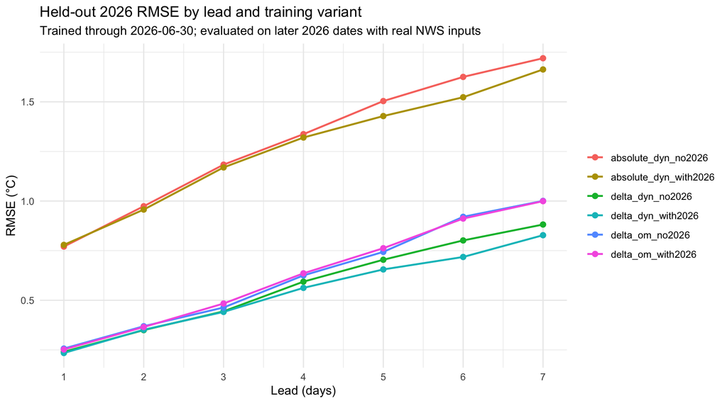

```r
results |>
  mutate(lead = as.integer(lead_days)) |>
  group_by(variant, lead) |>
  summarise(rmse = sqrt(mean(err^2)), .groups = "drop") |>
  ggplot(aes(x = lead, y = rmse, color = variant)) +
  geom_line(linewidth = 0.8) + geom_point(size = 2) +
  scale_x_continuous(breaks = lead_days_vec) +
  labs(title = "Held-out 2026 RMSE by lead and training variant",
       subtitle = sprintf("Trained through %s; evaluated on later 2026 dates with real NWS inputs", train_cutoff),
       x = "Lead (days)", y = "RMSE (°C)", color = NULL) +
  theme_minimal()
```

# 7. Interpretation

Lowest overall RMSE on the held-out period: **delta_dyn_with2026** (0.565 °C).

Points to weigh when reading the tables above.

**Summary of the three questions this document was built to answer.**

1. *Does adding 2026 help?* Yes, modestly and significantly, under both formulations (delta -0.038, absolute -0.043 RMSE). The gain concentrates at long leads, where the model depends least on the persistence anchor.
2. *Which formulation wins?* The change-from-today target, by 0.72 C RMSE — an order of magnitude larger than the 2026 effect, and consistent with prior evaluations.
3. *Is a longer record worth a weaker weather source?* No. The Open-Meteo variant is worse than dynamical.org despite training on ~50% more rows, and adding 2026 to it changes nothing.